# Winter Olympics

Author

Jo Hardin

Published

February 10, 2026

```r
library(tidyverse) # ggplot, lubridate, dplyr, stringr, readr...
library(praise)
```

## The Data

This week we’re exploring the event schedule for the 2026 Winter Olympics in Milan-Cortina, Italy. The dataset contains detailed information about all 1,866 Olympic events, including both competition and training sessions across various winter sport disciplines.

The dataset provides comprehensive scheduling information with start and end times in both local and UTC timezones, venue details, and metadata about each event such as whether it’s a medal event or training session. This dataset captures the full scope of Olympic events taking place from early February through the closing ceremonies, including the new ski mountaineering event.

> Ciao from Milano Cortina 2026

Some questions to explore: - Which sport disciplines have the most events scheduled? - How are medal events distributed across the days of the Olympics? - What is the typical duration of different types of events? - Which venues host the most events? - How does the schedule vary by day of the week? - What proportion of scheduled sessions are training versus competition?

For more information about how the data was collected and example code for creating the table in R or Python you can go to this repository: https://github.com/chendaniely/olympics-2026

```r
schedule <- readr::read_csv('https://raw.githubusercontent.com/rfordatascience/tidytuesday/main/data/2026/2026-02-10/schedule.csv') |>
  select(discipline_code, discipline_name, event_code,
         event_description, start_datetime_utc, end_datetime_utc,
         is_medal_event, venue_name, location_name, session_code, start_time) |>
  distinct() |>
  mutate(week = lubridate::week(start_datetime_utc),
         day = lubridate::yday(start_datetime_utc)) |>
  mutate(where = case_when(
    discipline_name == "Curling" ~ "Inside",
    discipline_name == "Figure Skating" ~ "Inside",
    discipline_name == "Ice Hockey" ~ "Inside",
    discipline_name == "Short Track Speed Skating" ~ "Inside",
    discipline_name == "Speed Skating" ~ "Inside",
    TRUE ~ "Outside"),
    surface = case_when(
      discipline_name == "Bobsleigh" ~ "Ice",
      discipline_name == "Curling" ~ "Ice",
      discipline_name == "Figure Skating" ~ "Ice",
      discipline_name == "Ice Hockey" ~ "Ice",
      discipline_name == "Luge" ~ "Ice",
      discipline_name == "Short Track Speed Skating" ~ "Ice",
      discipline_name == "Skeleton" ~ "Ice",
      discipline_name == "Speed Skating" ~ "Ice",
      TRUE ~ "Snow"
    ))
```

```r
schedule |>
  group_by(discipline_name) |>
  summarize(n())
```

```
# A tibble: 16 × 2
   discipline_name           `n()`
   <chr>                     <int>
 1 Alpine Skiing                39
 2 Biathlon                     11
 3 Bobsleigh                    40
 4 Cross-Country Skiing         20
 5 Curling                     147
 6 Figure Skating               16
 7 Freestyle Skiing             94
 8 Ice Hockey                   66
 9 Luge                         37
10 Nordic Combined              22
11 Short Track Speed Skating    38
12 Skeleton                     21
13 Ski Jumping                  29
14 Ski Mountaineering            7
15 Snowboard                    64
16 Speed Skating                26
```

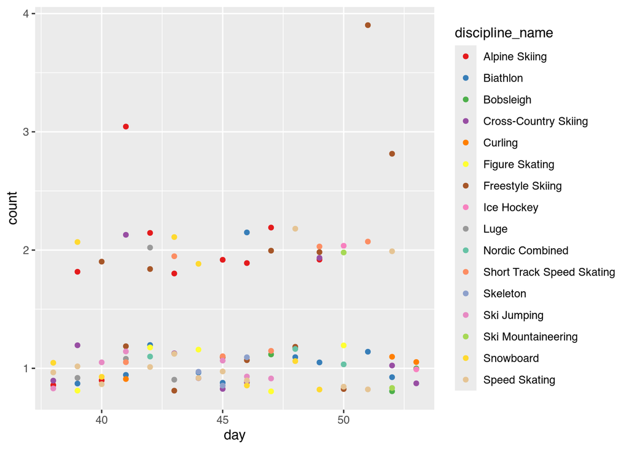

```r
my_palette <- c(
  "#E41A1C", "#377EB8", "#4DAF4A", "#984EA3", "#FF7F00", "#FFFF33",
  "#A65628", "#F781BF", "#999999", "#66C2A5", "#FC8D62", "#8DA0CB",
  "#E78AC3", "#A6D854", "#FFD92F", "#E5C494"
)


schedule |>
  filter(is_medal_event) |>
  group_by(discipline_name, day) |>
  summarize(count = n()) |>
  ggplot(aes(x = day, y = count, color = discipline_name)) +
  #geom_point()
  geom_jitter(width = 0, height = 0.2) +
  #geom_line() +
  scale_color_manual(values = my_palette)
```

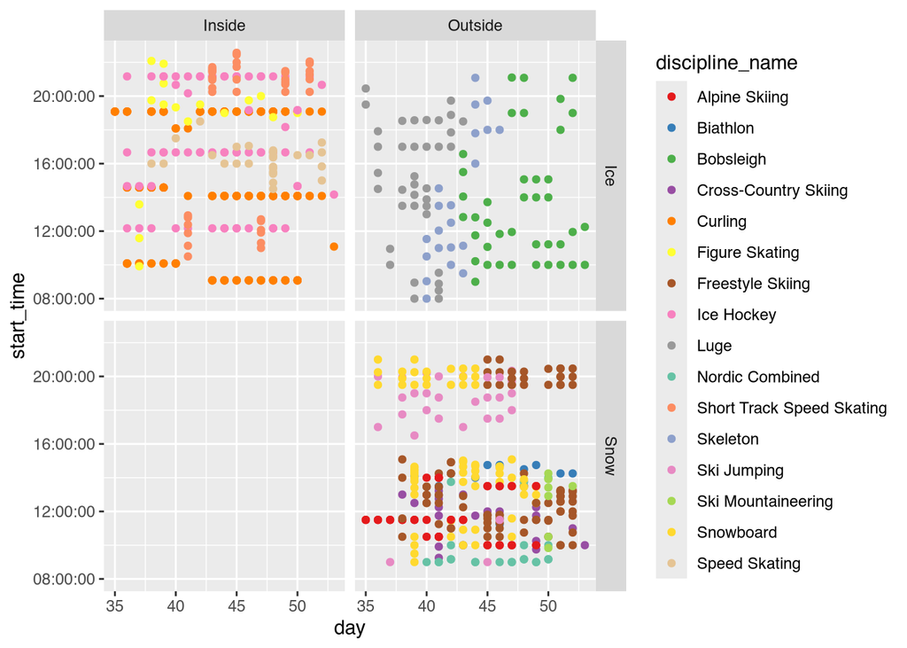

```r
schedule |>
  ggplot(aes(y = start_time, x = day, color = discipline_name )) +
  geom_point() +
  facet_grid(surface ~ where)  +
  scale_color_manual(values = my_palette)
```

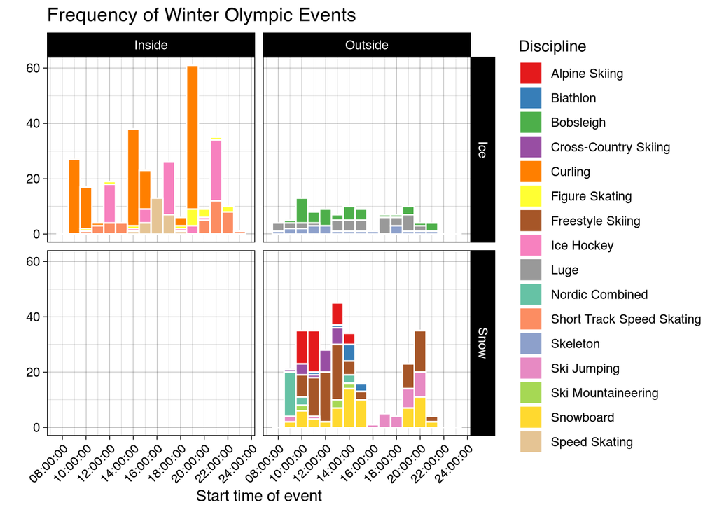

Using data from olympics.com, wikipedia, and kaggle, @chendaniely compiled information on all Winter Olympics events, including start time, venue location, and other metadata. In the histograms, we can see that some disciplines happen at all times during the day and other disciplines happen primarily in the morning or in the afternoon.

```r
schedule |>
  ggplot(aes(x = start_time,
             fill = discipline_name )) +
  geom_histogram(binwidth = 3600, color = "white") +
  facet_grid(surface ~ where)  +
  scale_fill_manual(values = my_palette) +
  scale_x_time(breaks = scales::breaks_width("2 hour")) +
  theme_linedraw() +
  theme(axis.text.x = element_text(angle = 45, hjust = 1)) +
  labs(x = "Start time of event",
       y = "",
       title = "Frequency of Winter Olympic Events",
       fill = "Discipline")
```

```r
praise()
```

```
[1] "You are extraordinary!"
```